# Final Project — EDA

Group 5

2026-06-11

```r
pkgs <- c("tidyverse", "caret", "corrplot", "ggcorrplot",
          "ggridges", "readxl", "writexl", "psych", "nortest",
          "car", "gridExtra")
lapply(pkgs, library, character.only = TRUE)
```

[output not shown]

[output cut: 60 more lines]

## 1 1. Data Loading and Variable Definitions

```r
df <- read_excel("~/Documents/strathmore/Modules/Module 3/linear_models/classwork/final_project/data/ENB2012_data 2.xlsx")
colnames(df) <- c(
  "RelCompactness", "SurfaceArea", "WallArea", "RoofArea",
  "OverallHeight", "Orientation", "GlazingArea",
  "GlazingAreaDist", "HeatingLoad", "CoolingLoad"
)
cat("Dimensions:", nrow(df), "rows x", ncol(df), "columns\n")
```

```
## Dimensions: 768 rows x 10 columns
```

## 2 2. Dataset Structure and the Combinatorial Grid

ENB2012 is not a sample of real buildings. It was generated by the EnergyPlus simulator by systematically varying eight building parameters across fixed discrete levels. This is important because it means the dataset has a combinatorial grid structure where every combination of parameter values appears exactly once (or a fixed number of times). The practical consequence is that a naive random train/test split will leak building configurations between sets, since orientation variants of the same building will appear in both. All downstream modelling accounts for this through a group-aware split.

```r
# Confirm the combinatorial structure
cat("Unique values per variable:\n")
```

```
## Unique values per variable:
```

```r
sapply(df, function(x) length(unique(x)))
```

```
##  RelCompactness     SurfaceArea        WallArea        RoofArea   OverallHeight
##              12              12               7               4               2
##     Orientation     GlazingArea GlazingAreaDist     HeatingLoad     CoolingLoad
##               4               4               6             587             636
```

```r
# The group key uniquely identifies each building configuration
# (everything except orientation)
df <- df %>%
  mutate(group_key = paste(RelCompactness, WallArea, RoofArea,
                           OverallHeight, GlazingArea, GlazingAreaDist,
                           sep = "_"))

cat("\nTotal rows:", nrow(df), "\n")
```

```
##
## Total rows: 768
```

```r
cat("Unique building configurations:", length(unique(df$group_key)), "\n")
```

```
## Unique building configurations: 192
```

```r
cat("Rows per configuration (should be 4 — one per orientation):\n")
```

```
## Rows per configuration (should be 4 — one per orientation):
```

```r
print(table(table(df$group_key)))
```

```
##
##   4
## 192
```

## 3 3. Missing Values, Duplicates, and Data Quality

```r
cat("Missing values per column:\n")
```

```
## Missing values per column:
```

```r
print(colSums(is.na(df)))
```

```
##  RelCompactness     SurfaceArea        WallArea        RoofArea   OverallHeight
##               0               0               0               0               0
##     Orientation     GlazingArea GlazingAreaDist     HeatingLoad     CoolingLoad
##               0               0               0               0               0
##       group_key
##               0
```

```r
cat("\nDuplicated rows:", sum(duplicated(df)), "\n")
```

```
##
## Duplicated rows: 0
```

ENB2012 has no missing values by construction. Any duplicated rows would indicate a simulation export error; none are present here.

## 4 4. Univariate Distributions

### 4.1 4.1 Continuous variables

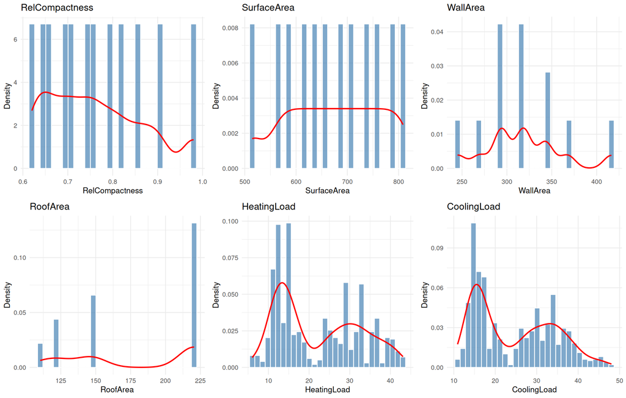

```r
cont_vars <- c("RelCompactness", "SurfaceArea", "WallArea",
               "RoofArea", "HeatingLoad", "CoolingLoad")

p_hist <- lapply(cont_vars, function(v) {
  ggplot(df, aes(x = .data[[v]])) +
    geom_histogram(aes(y = after_stat(density)), bins = 30,
                   fill = "steelblue", color = "white", alpha = 0.7) +
    geom_density(color = "red", linewidth = 0.8) +
    labs(title = v, x = v, y = "Density") +
    theme_minimal(base_size = 10)
})
do.call(grid.arrange, c(p_hist, ncol = 3))
```

`RelCompactness` is roughly uniform across its range, which reflects the systematic grid design. `HeatingLoad` and `CoolingLoad` are both multimodal, with the modes corresponding to the two levels of `OverallHeight`. This bimodality is not noise; it is a structural feature of the data and motivates treating `OverallHeight` as a key stratifying variable throughout the analysis.

### 4.2 4.2 Discrete and categorical variables

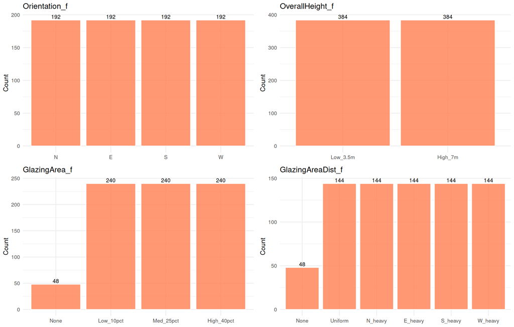

```r
df$Orientation_f   <- factor(df$Orientation,   levels = 2:5,
                              labels = c("N", "E", "S", "W"))
df$OverallHeight_f <- factor(df$OverallHeight,  levels = c(3.5, 7.0),
                              labels = c("Low_3.5m", "High_7m"))
df$GlazingArea_f   <- factor(df$GlazingArea,   levels = c(0, 0.1, 0.25, 0.4),
                              labels = c("None","Low_10pct","Med_25pct","High_40pct"))
df$GlazingAreaDist_f <- factor(df$GlazingAreaDist, levels = 0:5,
                                labels = c("None","Uniform","N_heavy",
                                           "E_heavy","S_heavy","W_heavy"))

cat_vars <- c("Orientation_f", "OverallHeight_f",
              "GlazingArea_f", "GlazingAreaDist_f")

p_bar <- lapply(cat_vars, function(v) {
  ggplot(df, aes(x = .data[[v]])) +
    geom_bar(fill = "coral", color = "white", alpha = 0.8) +
    geom_text(stat = "count", aes(label = after_stat(count)), vjust = -0.3,
              size = 3) +
    labs(title = v, x = NULL, y = "Count") +
    theme_minimal(base_size = 10)
})
do.call(grid.arrange, c(p_bar, ncol = 2))
```

All four orientation values appear in equal frequency (192 buildings each), confirming the balanced grid design. `GlazingAreaDist` level 0 (no distribution) corresponds exactly to buildings with zero `GlazingArea`, which creates a structural dependency between these two variables.

## 5 5. Response Variable Analysis

### 5.1 5.1 Normality assessment

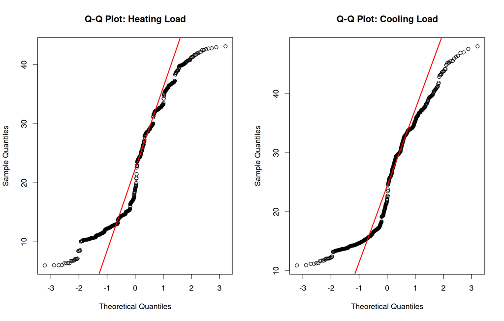

```r
par(mfrow = c(1, 2))
qqnorm(df$HeatingLoad, main = "Q-Q Plot: Heating Load")
qqline(df$HeatingLoad, col = "red", lwd = 2)
qqnorm(df$CoolingLoad, main = "Q-Q Plot: Cooling Load")
qqline(df$CoolingLoad, col = "red", lwd = 2)
```

```r
par(mfrow = c(1, 1))

cat("Anderson-Darling test — Heating Load:\n")
```

```
## Anderson-Darling test — Heating Load:
```

```r
print(nortest::ad.test(df$HeatingLoad))
```

```
##
##  Anderson-Darling normality test
##
## data:  df$HeatingLoad
## A = 26.863, p-value < 2.2e-16
```

```r
cat("\nAnderson-Darling test — Cooling Load:\n")
```

```
##
## Anderson-Darling test — Cooling Load:
```

```r
print(nortest::ad.test(df$CoolingLoad))
```

```
##
##  Anderson-Darling normality test
##
## data:  df$CoolingLoad
## A = 27.122, p-value < 2.2e-16
```

Both responses deviate significantly from normality, consistent with their multimodal distributions. This does not invalidate linear regression but it does mean residual diagnostics will matter, and it motivates exploring nonlinear and classification approaches alongside the linear models.

### 5.2 5.2 Distribution by Overall Height

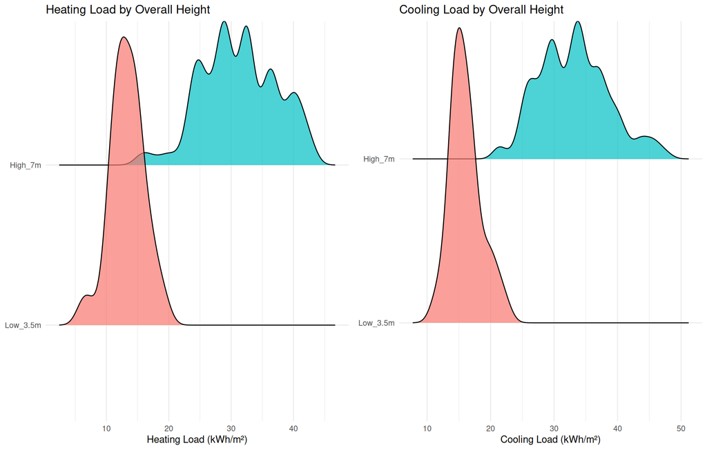

```r
library(ggridges)
p_rl1 <- ggplot(df, aes(x = HeatingLoad, y = OverallHeight_f,
                         fill = OverallHeight_f)) +
  geom_density_ridges(alpha = 0.7) +
  labs(title = "Heating Load by Overall Height",
       x = "Heating Load (kWh/m²)", y = NULL) +
  theme_minimal() + theme(legend.position = "none")

p_rl2 <- ggplot(df, aes(x = CoolingLoad, y = OverallHeight_f,
                         fill = OverallHeight_f)) +
  geom_density_ridges(alpha = 0.7) +
  labs(title = "Cooling Load by Overall Height",
       x = "Cooling Load (kWh/m²)", y = NULL) +
  theme_minimal() + theme(legend.position = "none")

grid.arrange(p_rl1, p_rl2, ncol = 2)
```

## 6 6. Feature-Response Relationships

### 6.1 6.1 Scatter plots with LOESS smooths

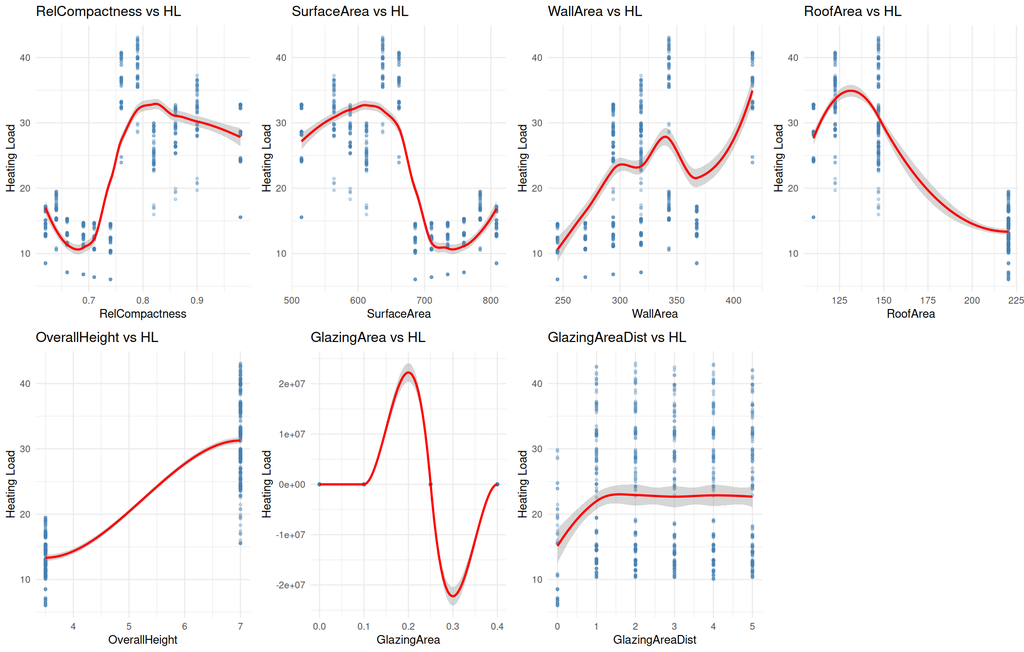

```r
feature_vars <- c("RelCompactness", "SurfaceArea", "WallArea", "RoofArea",
                  "OverallHeight", "GlazingArea", "GlazingAreaDist")

p_y1 <- lapply(feature_vars, function(v) {
  ggplot(df, aes(x = .data[[v]], y = HeatingLoad)) +
    geom_point(alpha = 0.3, color = "steelblue", size = 0.8) +
    geom_smooth(method = "loess", color = "red", se = TRUE,
                linewidth = 0.8) +
    labs(title = paste(v, "vs HL"), x = v, y = "Heating Load") +
    theme_minimal(base_size = 9)
})
do.call(grid.arrange, c(p_y1, ncol = 4))
```

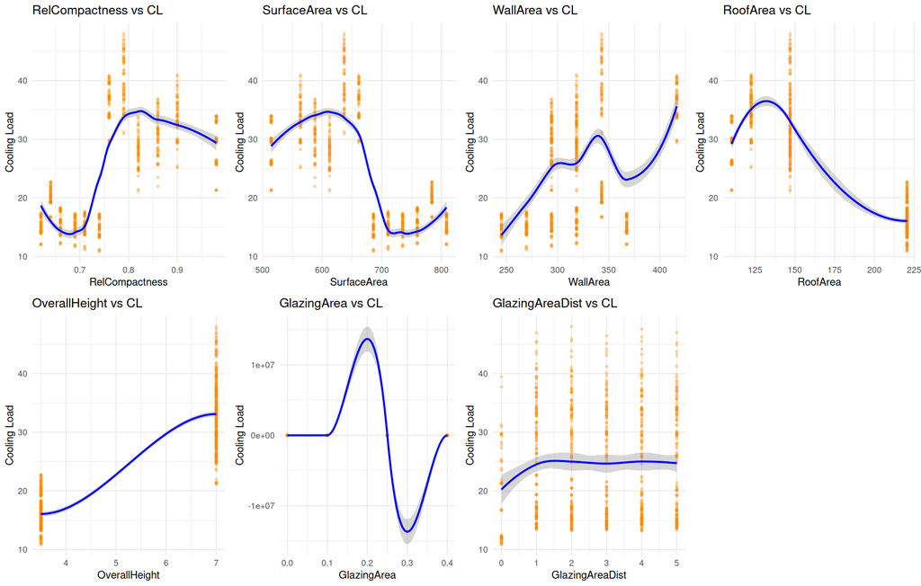

```r
p_y2 <- lapply(feature_vars, function(v) {
  ggplot(df, aes(x = .data[[v]], y = CoolingLoad)) +
    geom_point(alpha = 0.3, color = "darkorange", size = 0.8) +
    geom_smooth(method = "loess", color = "blue", se = TRUE,
                linewidth = 0.8) +
    labs(title = paste(v, "vs CL"), x = v, y = "Cooling Load") +
    theme_minimal(base_size = 9)
})
do.call(grid.arrange, c(p_y2, ncol = 4))
```

### 6.2 6.2 Interaction: OverallHeight × GlazingArea

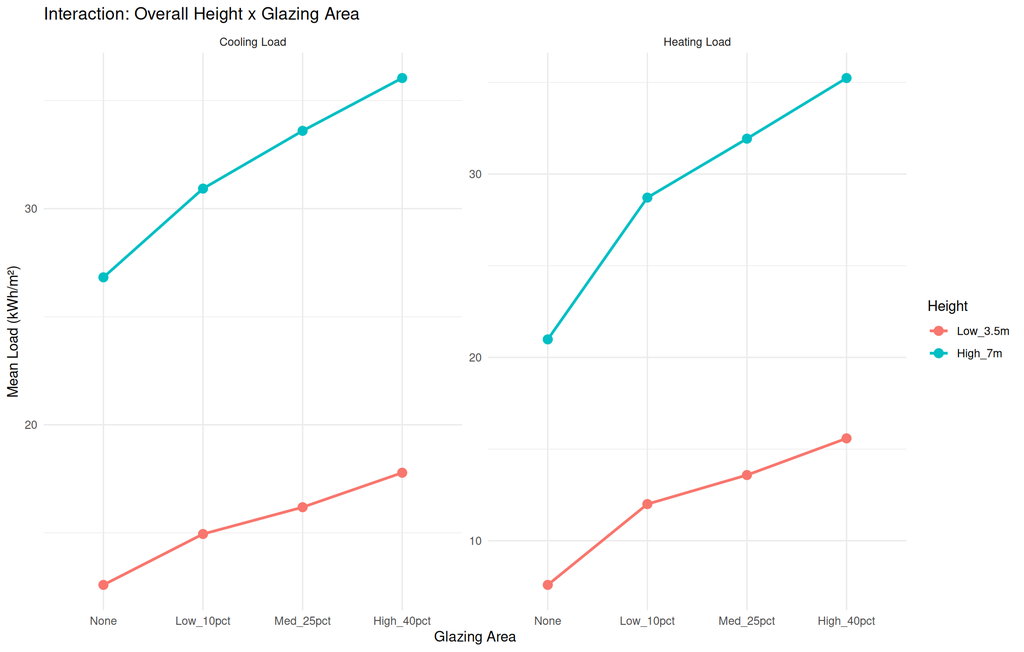

```r
df %>%
  group_by(OverallHeight_f, GlazingArea_f) %>%
  summarise(mean_HL = mean(HeatingLoad),
            mean_CL = mean(CoolingLoad), .groups = "drop") %>%
  pivot_longer(c(mean_HL, mean_CL),
               names_to = "Response", values_to = "Mean") %>%
  mutate(Response = case_when(Response == "mean_HL" ~ "Heating Load",
                              Response == "mean_CL" ~ "Cooling Load"
                              )) %>%
  ggplot(aes(x = GlazingArea_f, y = Mean,
             color = OverallHeight_f, group = OverallHeight_f)) +
  geom_line(linewidth = 1) +
  geom_point(size = 3) +
  facet_wrap(~ Response, scales = "free_y") +
  labs(title = "Interaction: Overall Height x Glazing Area",
       x = "Glazing Area", y = "Mean Load (kWh/m²)",
       color = "Height") +
  theme_minimal()
```

## 7 7. Correlation and Multicollinearity

### 7.1 7.1 Correlation heatmap

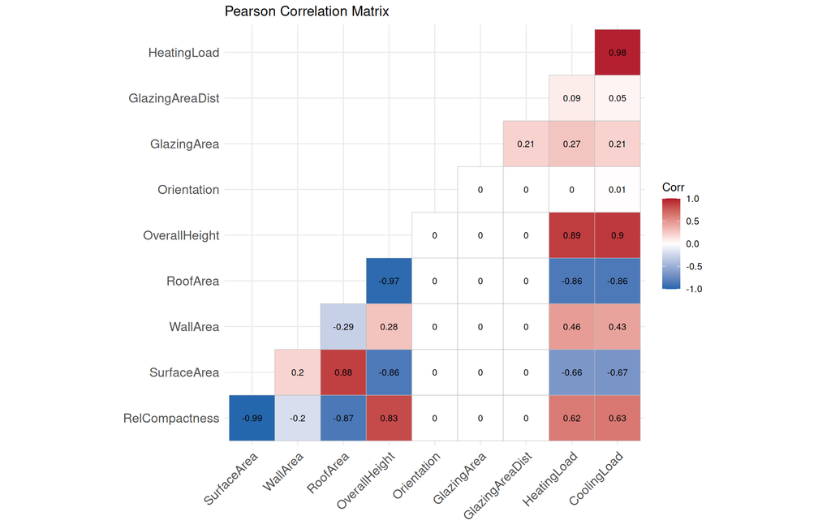

```r
cor_matrix <- cor(df %>% dplyr::select(RelCompactness:CoolingLoad),
                  method = "pearson")

ggcorrplot(cor_matrix, type = "lower", lab = TRUE, lab_size = 3,
           colors = c("#2166AC", "white", "#B2182B"),
           title = "Pearson Correlation Matrix",
           ggtheme = theme_minimal())
```

`SurfaceArea` is almost perfectly negatively correlated with `RelCompactness` (r ≈ −0.99). This is a mathematical near-identity: relative compactness is defined as the ratio of the volume to the surface area, so the two variables carry almost identical information in opposite directions. Including both in a linear model will cause exact or near-exact multicollinearity.

`HeatingLoad` and `CoolingLoad` are highly correlated (r ≈ 0.98), reflecting that the same physical factors drive both. They are modelled separately throughout this project.

### 7.2 7.2 VIF analysis

```r
prelim_model <- lm(HeatingLoad ~ RelCompactness + WallArea + RoofArea +
                     OverallHeight + Orientation + GlazingArea +
                     GlazingAreaDist, data = df)

cat("VIF — SurfaceArea excluded to resolve perfect collinearity:\n")
```

```
## VIF — SurfaceArea excluded to resolve perfect collinearity:
```

```r
print(car::vif(prelim_model))
```

```
##  RelCompactness        WallArea        RoofArea   OverallHeight     Orientation
##      105.524054       27.662740      211.938336       31.205474        1.000000
##     GlazingArea GlazingAreaDist
##        1.047508        1.047508
```

`SurfaceArea` is excluded from this VIF calculation because it is a linear combination of `WallArea` and `RoofArea`, which causes the model matrix to be rank-deficient. `SurfaceArea` is excluded from all subsequent models for the same reason.

Excluding SurfaceArea resolves the rank deficiency but does not resolve the multicollinearity. The remaining VIF values reveal severe inflation across several features:

- RoofArea (VIF = 211.9) and RelCompactness (VIF = 105.5) are the worst offenders, indicating that these variables are almost entirely explained by linear combinations of the other predictors in the model.
- WallArea (VIF = 27.7) and OverallHeight (VIF = 31.2) also show severe multicollinearity well above the conventional threshold of 10.
- Orientation (VIF = 1.0), GlazingArea (VIF = 1.05), and GlazingAreaDist (VIF = 1.05) are clean with no inflation.

This level of multicollinearity is again a consequence of the combinatorial grid structure of ENB2012. RelCompactness is a deterministic function of SurfaceArea, WallArea, RoofArea, and OverallHeight, so even after removing SurfaceArea the remaining geometric variables remain tightly linearly dependent. Standard OLS coefficient estimates under these conditions will be unstable and their standard errors inflated, making individual coefficient significance tests unreliable.

This motivates two decisions in the modelling phase. First, regularised regression methods such as Ridge and Elastic Net are preferred over plain OLS because they are designed to handle correlated predictors by shrinking coefficients rather than relying on matrix inversion stability. Second, feature importance rankings from tree-based models should be interpreted with caution since correlated features will split importance arbitrarily between themselves.

## 8 8. Outlier Assessment

```r
detect_outliers <- function(x) {
  q1  <- quantile(x, 0.25)
  q3  <- quantile(x, 0.75)
  iqr <- q3 - q1
  sum(x < (q1 - 1.5 * iqr) | x > (q3 + 1.5 * iqr))
}

cat("IQR-based outlier counts:\n")
```

```
## IQR-based outlier counts:
```

```r
print(sapply(df %>% dplyr::select(RelCompactness:CoolingLoad),
             detect_outliers))
```

```
##  RelCompactness     SurfaceArea        WallArea        RoofArea   OverallHeight
##               0               0               0               0               0
##     Orientation     GlazingArea GlazingAreaDist     HeatingLoad     CoolingLoad
##               0               0               0               0               0
```

## 9 9. Export

```r
library(writexl)
write_xlsx(df, "ENB2012_post_EDA.xlsx")
cat("Exported: ENB2012_post_EDA.xlsx\n")
```

```
## Exported: ENB2012_post_EDA.xlsx
```

```r
cat("Dimensions:", nrow(df), "rows x", ncol(df), "columns\n")
```

```
## Dimensions: 768 rows x 15 columns
```